# Principal Component Analysis - FIFA 2019 Data

Sau Kha

# Dataset Introduction

Data Source - https://www.kaggle.com/karangadiya/fifa19  
Context - Football analytics  
Content - Detailed skills for every player registered in the latest edition of FIFA 19 database.  
Scraping code at GitHub repo - https://github.com/amanthedorkknight/fifa18-all-player-statistics/tree/master/2019  
Acknowledgements - Data scraped from https://sofifa.com/  
Inspiration from this dataset - https://www.kaggle.com/thec03u5/fifa-18-demo-player-dataset  
This dataset includes lastest edition FIFA 2019 players skills like Age, Nationality, Overall, Potential, Club, Value, Wage, Preferred Foot, International Reputation, Weak Foot, Skill Moves, Work Rate, Position, Jersey Number, Joined, Loaned From, Contract Valid Until, Height, Weight, LS, ST, RS, LW, LF, CF, RF, RW, LAM, CAM, RAM, LM, LCM, CM, RCM, RM, LWB, LDM, CDM, RDM, RWB, LB, LCB, CB, RCB, RB, Crossing, Finishing, Heading, Accuracy, ShortPassing, Volleys, Dribbling, Curve, FKAccuracy, LongPassing, BallControl, Acceleration, SprintSpeed, Agility, Reactions, Balance, ShotPower, Jumping, Stamina, Strength, LongShots, Aggression, Interceptions, Positioning, Vision, Penalties, Composure, Marking, StandingTackle, SlidingTackle, GKDiving, GKHandling, GKKicking, GKPositioning, GKReflees, and Release Clause. Columns LS, ST, RS, LW, LF, CF, RF, RW, LAM, CAM, RAM, LM, LCM, CM, RCM, RM, LWB, LDM, CDM, RDM, RWB, LB, LCB, CB, RCB, RB list the rating for the position in the scale of 100.

```r
# load library
library(dplyr)
```

```r
library(tibble)
library(utils)
library(ggplot2)
library(corrplot)
library(caTools)
```

# Data Exploration

```r
# Import the data and look at the first six rows
df <- read.csv(file = 'data.csv')

# df <- read_csv(file = 'data.csv', col_names = TRUE, skip_empty_rows = TRUE)
head(df)
```

|  | ï.. | ID | Name | Age | Photo | Nationality | Flag | Overall | Potential | Club | Club.Logo | Value | Wage | Special | Preferred.Foot | International.Reputation | Weak.Foot | Skill.Moves | Work.Rate | Body.Type | Real.Face | Position | Jersey.Number | Joined | Loaned.From | Contract.Valid.Until | Height | Weight | LS | … |
| --- | --- | --- | --- | --- | --- | --- | --- | --- | --- | --- | --- | --- | --- | --- | --- | --- | --- | --- | --- | --- | --- | --- | --- | --- | --- | --- | --- | --- | --- | --- |
| 1 | 0 | 158023 | L. Messi | 31 | https://cdn.sofifa.org/players/4/19/158023.png | Argentina | https://cdn.sofifa.org/flags/52.png | 94 | 94 | FC Barcelona | https://cdn.sofifa.org/teams/2/light/241.png | â‚¬110.5M | â‚¬565K | 2202 | Left | 5 | 4 | 4 | Medium/ Medium | Messi | Yes | RF | 10 | Jul 1, 2004 |  | 2021 | 5'7 | 159lbs | 88+2 | … |
| 2 | 1 | 20801 | Cristiano Ronaldo | 33 | https://cdn.sofifa.org/players/4/19/20801.png | Portugal | https://cdn.sofifa.org/flags/38.png | 94 | 94 | Juventus | https://cdn.sofifa.org/teams/2/light/45.png | â‚¬77M | â‚¬405K | 2228 | Right | 5 | 4 | 5 | High/ Low | C. Ronaldo | Yes | ST | 7 | Jul 10, 2018 |  | 2022 | 6'2 | 183lbs | 91+3 | … |
| 3 | 2 | 190871 | Neymar Jr | 26 | https://cdn.sofifa.org/players/4/19/190871.png | Brazil | https://cdn.sofifa.org/flags/54.png | 92 | 93 | Paris Saint-Germain | https://cdn.sofifa.org/teams/2/light/73.png | â‚¬118.5M | â‚¬290K | 2143 | Right | 5 | 5 | 5 | High/ Medium | Neymar | Yes | LW | 10 | Aug 3, 2017 |  | 2022 | 5'9 | 150lbs | 84+3 | … |
| 4 | 3 | 193080 | De Gea | 27 | https://cdn.sofifa.org/players/4/19/193080.png | Spain | https://cdn.sofifa.org/flags/45.png | 91 | 93 | Manchester United | https://cdn.sofifa.org/teams/2/light/11.png | â‚¬72M | â‚¬260K | 1471 | Right | 4 | 3 | 1 | Medium/ Medium | Lean | Yes | GK | 1 | Jul 1, 2011 |  | 2020 | 6'4 | 168lbs |  | … |
| 5 | 4 | 192985 | K. De Bruyne | 27 | https://cdn.sofifa.org/players/4/19/192985.png | Belgium | https://cdn.sofifa.org/flags/7.png | 91 | 92 | Manchester City | https://cdn.sofifa.org/teams/2/light/10.png | â‚¬102M | â‚¬355K | 2281 | Right | 4 | 5 | 4 | High/ High | Normal | Yes | RCM | 7 | Aug 30, 2015 |  | 2023 | 5'11 | 154lbs | 82+3 | … |
| 6 | 5 | 183277 | E. Hazard | 27 | https://cdn.sofifa.org/players/4/19/183277.png | Belgium | https://cdn.sofifa.org/flags/7.png | 91 | 91 | Chelsea | https://cdn.sofifa.org/teams/2/light/5.png | â‚¬93M | â‚¬340K | 2142 | Right | 4 | 4 | 4 | High/ Medium | Normal | Yes | LF | 10 | Jul 1, 2012 |  | 2020 | 5'8 | 163lbs | 83+3 | … |

```r
# get the summary of the data
summary(df)
```

```
##       ï..              ID             Name                Age
##  Min.   :    0   Min.   :    16   Length:18207       Min.   :16.00
##  1st Qu.: 4552   1st Qu.:200316   Class :character   1st Qu.:21.00
##  Median : 9103   Median :221759   Mode  :character   Median :25.00
##  Mean   : 9103   Mean   :214298                      Mean   :25.12
##  3rd Qu.:13654   3rd Qu.:236530                      3rd Qu.:28.00
##  Max.   :18206   Max.   :246620                      Max.   :45.00
##
##     Photo           Nationality            Flag              Overall
##  Length:18207       Length:18207       Length:18207       Min.   :46.00
##  Class :character   Class :character   Class :character   1st Qu.:62.00
##  Mode  :character   Mode  :character   Mode  :character   Median :66.00
##                                                           Mean   :66.24
##                                                           3rd Qu.:71.00
##                                                           Max.   :94.00
##
##    Potential         Club            Club.Logo            Value
##  Min.   :48.00   Length:18207       Length:18207       Length:18207
##  1st Qu.:67.00   Class :character   Class :character   Class :character
##  Median :71.00   Mode  :character   Mode  :character   Mode  :character
##  Mean   :71.31
##  3rd Qu.:75.00
##  Max.   :95.00
##
##      Wage              Special     Preferred.Foot     International.Reputation
##  Length:18207       Min.   : 731   Length:18207       Min.   :1.000
##  Class :character   1st Qu.:1457   Class :character   1st Qu.:1.000
##  Mode  :character   Median :1635   Mode  :character   Median :1.000
##                     Mean   :1598                      Mean   :1.113
##                     3rd Qu.:1787                      3rd Qu.:1.000
##                     Max.   :2346                      Max.   :5.000
##                                                       NA's   :48
##    Weak.Foot      Skill.Moves     Work.Rate          Body.Type
##  Min.   :1.000   Min.   :1.000   Length:18207       Length:18207
##  1st Qu.:3.000   1st Qu.:2.000   Class :character   Class :character
##  Median :3.000   Median :2.000   Mode  :character   Mode  :character
##  Mean   :2.947   Mean   :2.361
##  3rd Qu.:3.000   3rd Qu.:3.000
##  Max.   :5.000   Max.   :5.000
##  NA's   :48      NA's   :48
```

[output cut: 121 more lines]

```
##  Min.   : 1.00   Min.   : 1.00   Min.   : 1.00   Min.   : 1.00
##  1st Qu.: 8.00   1st Qu.: 8.00   1st Qu.: 8.00   1st Qu.: 8.00
##  Median :11.00   Median :11.00   Median :11.00   Median :11.00
##  Mean   :16.62   Mean   :16.39   Mean   :16.23   Mean   :16.39
##  3rd Qu.:14.00   3rd Qu.:14.00   3rd Qu.:14.00   3rd Qu.:14.00
##  Max.   :90.00   Max.   :92.00   Max.   :91.00   Max.   :90.00
##  NA's   :48      NA's   :48      NA's   :48      NA's   :48
##    GKReflexes    Release.Clause
##  Min.   : 1.00   Length:18207
##  1st Qu.: 8.00   Class :character
##  Median :11.00   Mode  :character
##  Mean   :16.71
##  3rd Qu.:14.00
##  Max.   :94.00
##  NA's   :48
```

```r
glimpse(df)
```

```
## Rows: 18,207
## Columns: 89
## $ ï..                      <int> 0, 1, 2, 3, 4, 5, 6, 7, 8, 9, 10, 11, 12, ...
## $ ID                       <int> 158023, 20801, 190871, 193080, 192985, 183...
## $ Name                     <chr> "L. Messi", "Cristiano Ronaldo", "Neymar J...
## $ Age                      <int> 31, 33, 26, 27, 27, 27, 32, 31, 32, 25, 29...
## $ Photo                    <chr> "https://cdn.sofifa.org/players/4/19/15802...
## $ Nationality              <chr> "Argentina", "Portugal", "Brazil", "Spain"...
## $ Flag                     <chr> "https://cdn.sofifa.org/flags/52.png", "ht...
## $ Overall                  <int> 94, 94, 92, 91, 91, 91, 91, 91, 91, 90, 90...
## $ Potential                <int> 94, 94, 93, 93, 92, 91, 91, 91, 91, 93, 90...
## $ Club                     <chr> "FC Barcelona", "Juventus", "Paris Saint-G...
## $ Club.Logo                <chr> "https://cdn.sofifa.org/teams/2/light/241....
## $ Value                    <chr> "â‚¬110.5M", "â‚¬77M", "â‚¬118.5M", "â‚¬72...
## $ Wage                     <chr> "â‚¬565K", "â‚¬405K", "â‚¬290K", "â‚¬260K"...
```

[output cut: 76 more lines]

```r
# date cleaning
df <- na.omit(df)

df$International.Reputation <- as.factor(df$International.Reputation)  # convert char type to factor
df$International.Reputation <- as.ordered(df$International.Reputation) # ordered factor
colnames(df)
```

```
##  [1] "ï.."                      "ID"
##  [3] "Name"                     "Age"
##  [5] "Photo"                    "Nationality"
##  [7] "Flag"                     "Overall"
##  [9] "Potential"                "Club"
## [11] "Club.Logo"                "Value"
## [13] "Wage"                     "Special"
## [15] "Preferred.Foot"           "International.Reputation"
## [17] "Weak.Foot"                "Skill.Moves"
## [19] "Work.Rate"                "Body.Type"
## [21] "Real.Face"                "Position"
## [23] "Jersey.Number"            "Joined"
## [25] "Loaned.From"              "Contract.Valid.Until"
## [27] "Height"                   "Weight"
## [29] "LS"                       "ST"
```

[output cut: 30 more lines]

After reviewing a glimpse of the data, I decided to take a closer look at the following features: Preferred.Foot, International.Reputation, Weak.Foot, Skill.Moves, Work.Rate, Body.Type, Position, HeadingAccuracy, ShortPassing, Volleys, Dribbling, Curve, FKAccuracy, LongPassing, BallControl, Acceleration, SprintSpeed, Agility, Reactions, Balance, ShotPower, Jumping, Stamina, Strength, LongShots, Aggression, Interceptions, Positioning, Vision, Penalties, Composure, Marking, StandingTackle, SlidingTackle, GKDiving, GKHandling, GKKicking, GKPositioning and GKReflees. I’d like to explore how these player’s skills may be used to predict player’s Overall rating and International Reputation.

# Visualization, e.g. scatter plot, hist, boxplot, etc

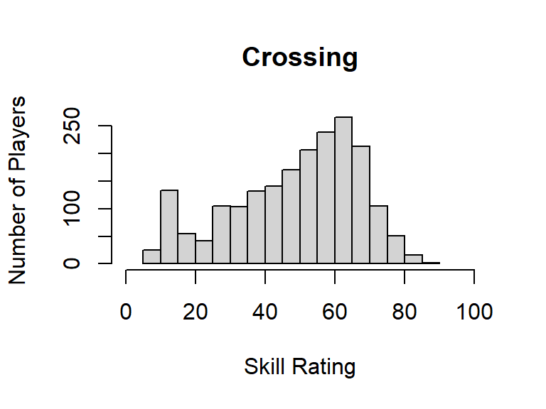

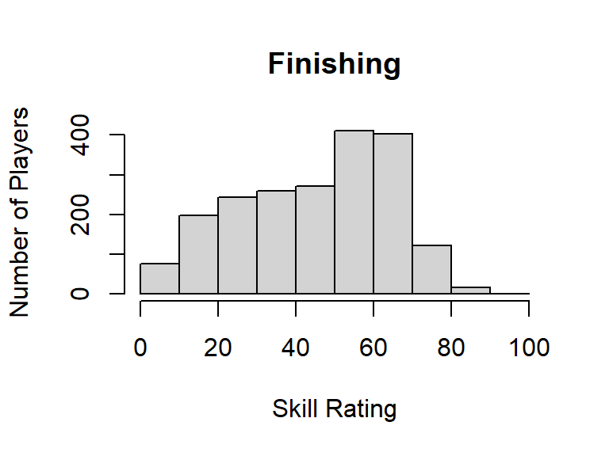

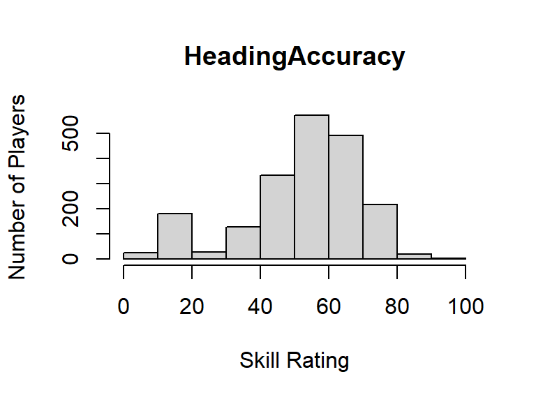

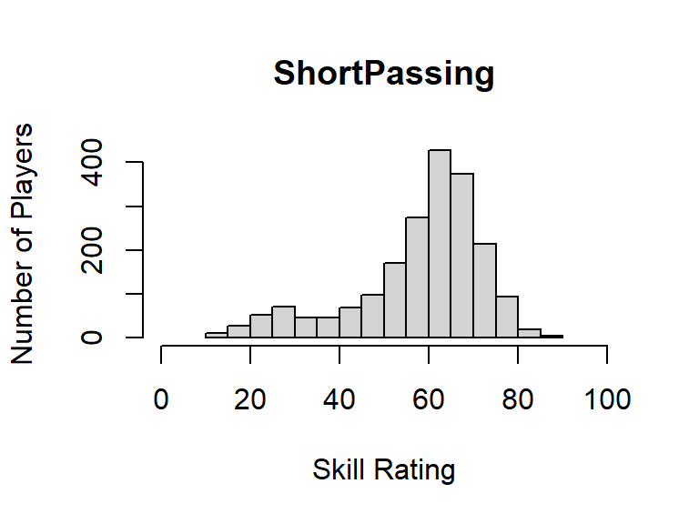

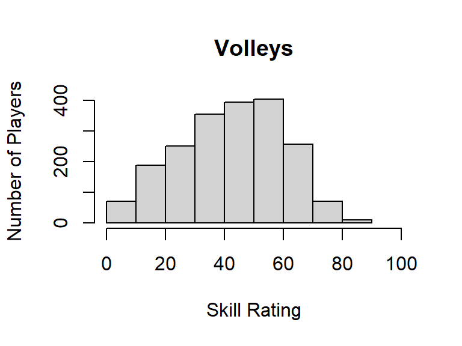

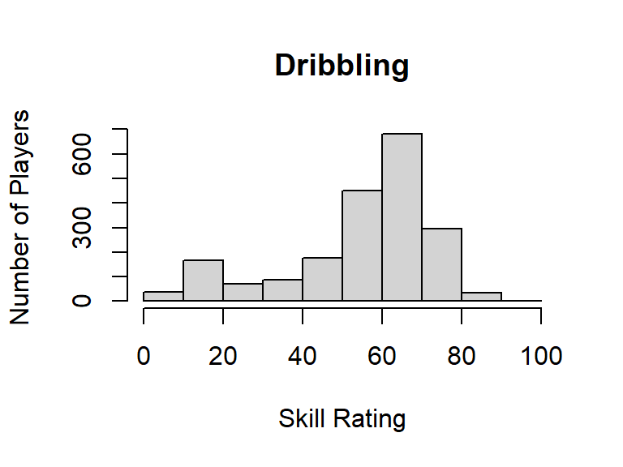

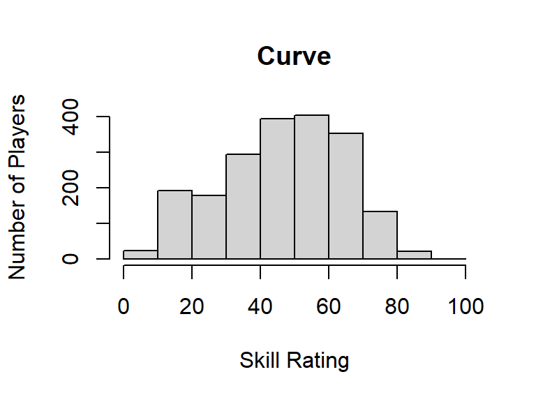

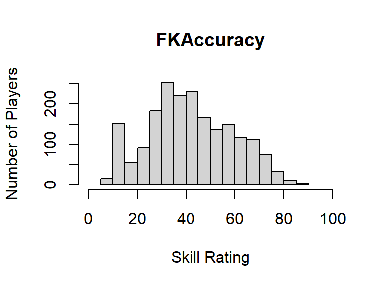

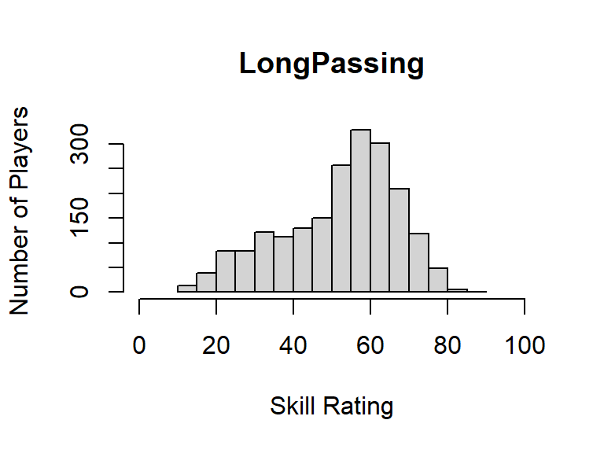

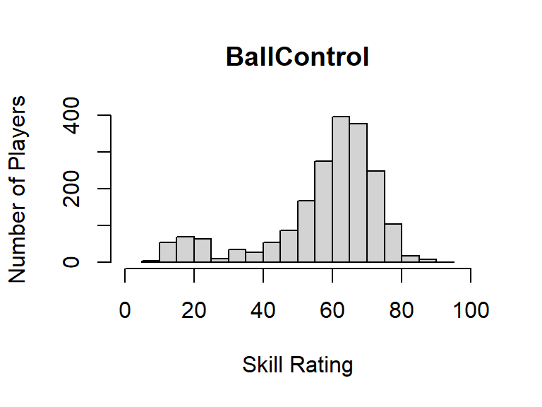

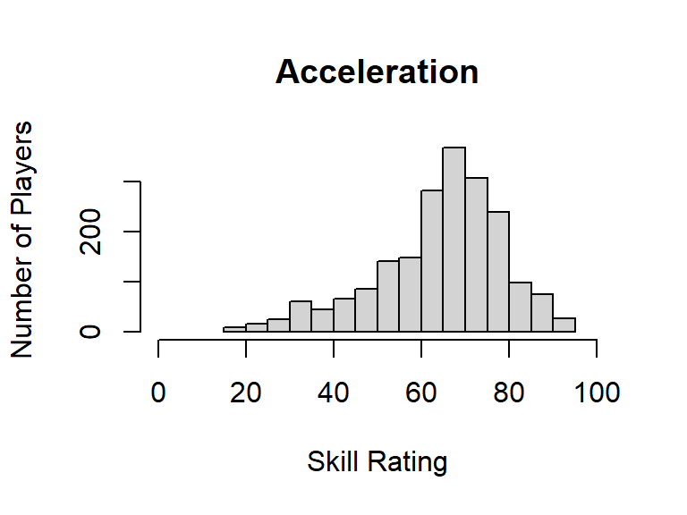

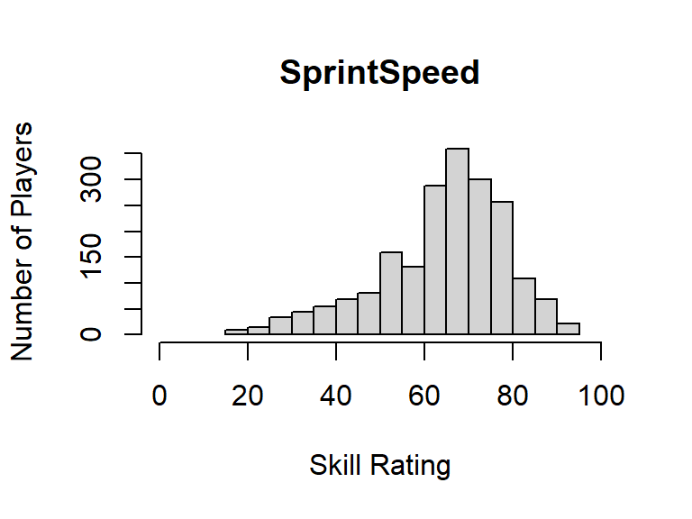

[22 more figures not shown]

```r
# pick random samples for coding for this assignment
set.seed(10)
df2000 <- df[sample(nrow(df), 2000), ]
# explore the numeric independent features of the dataset
# df2000_skills <- df2000[55:88]

# histogram per skill rating
# par(mfrow = c(7, 5))
for (i in 55:88) {
  hist(df2000[ , i], main = colnames(df2000[i]), xlim = c(0, 100),
       xlab = "Skill Rating", ylab = "Number of Players")
}
```

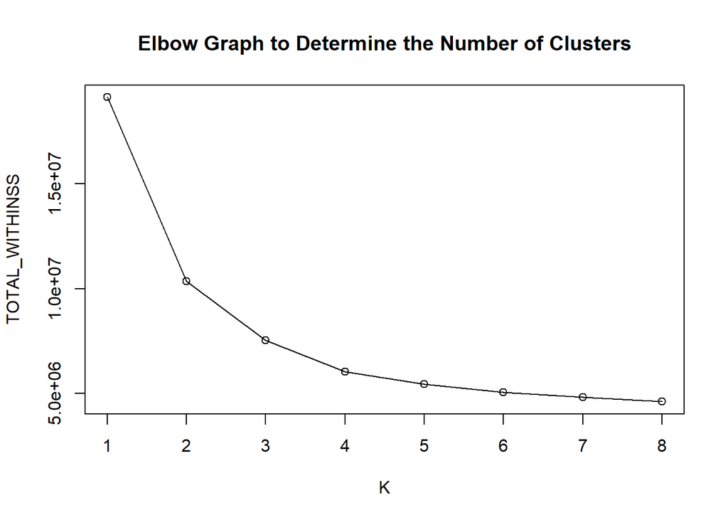

```r
# determine k for kmeans cluttering
# run kmeans() from R in each loop from K = 1 through 8, saving the tot.withinss for each loop
K <- c() # initialize vector for Elbow Graph
TOTAL_WITHINSS <- c() # initialize vector for Elbow Graph, cl$tot.withinss
for (i in 1:8) {
  cl <- kmeans(as.matrix(df2000[55:88]), i, nstart = 25, iter.max = 20)
  K <- c(K,i)
  TOTAL_WITHINSS <- c(TOTAL_WITHINSS, cl$tot.withinss)
}
# create elbow graph
plot(K, TOTAL_WITHINSS, main = "Elbow Graph to Determine the Number of Clusters")
lines(K, TOTAL_WITHINSS)
```

The Elbow Graph indicates that there are possibly two or more clusters in the dataset. Since the total within-cluster variation (TOTAL WITHNSS) do not drop as much when K = 3 and 4, more clustering do not reduce the within group variance as much. So I ran kmeans clustering on the dataset with k = 2 and visualize the clusters in scatterplots of player’s overall rating against each skills rating separately.

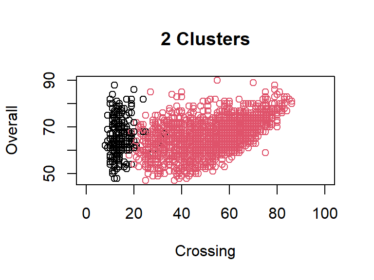

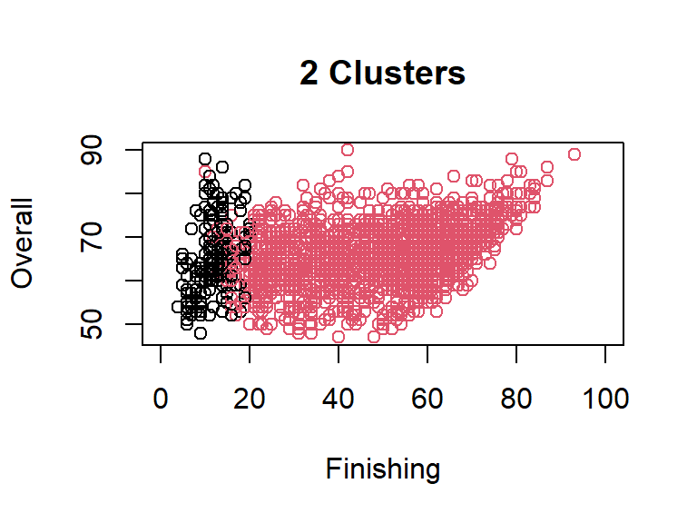

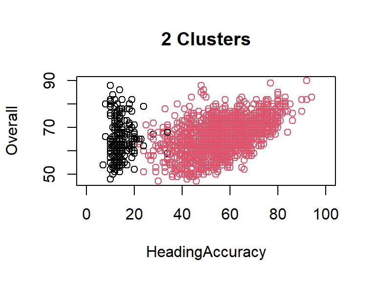

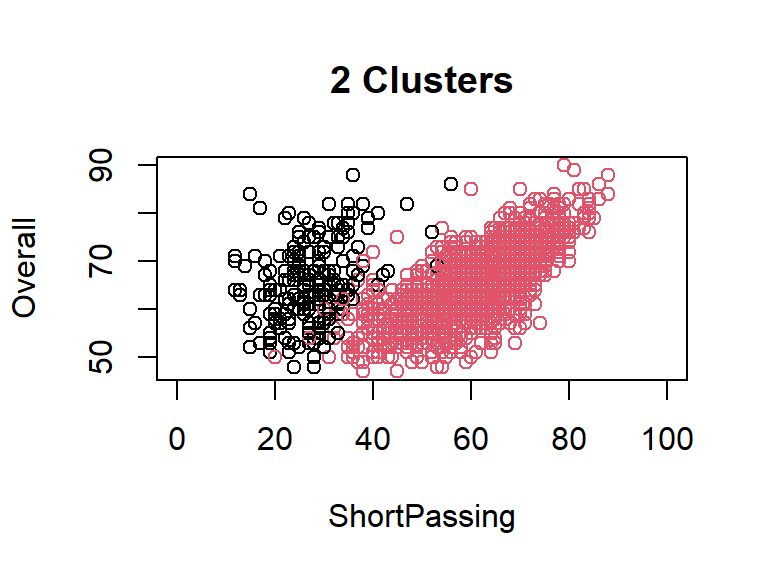

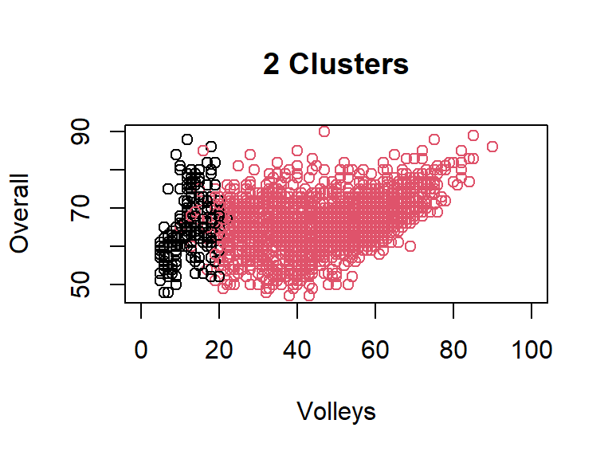

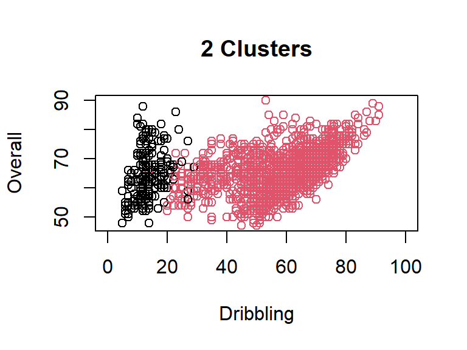

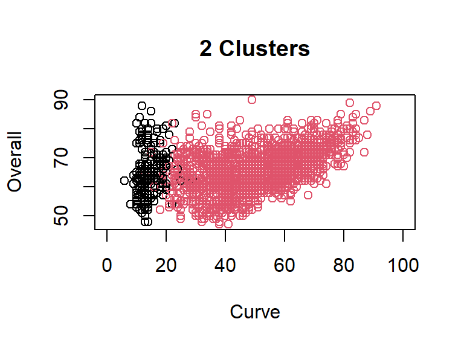

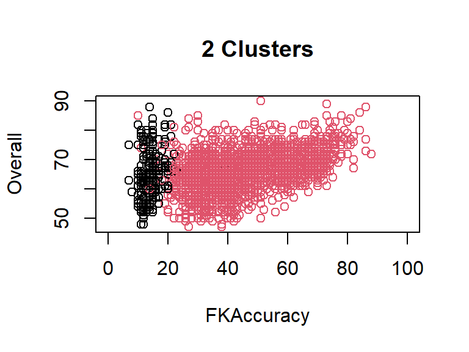

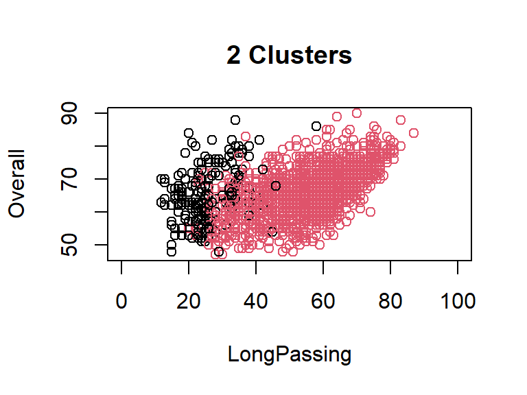

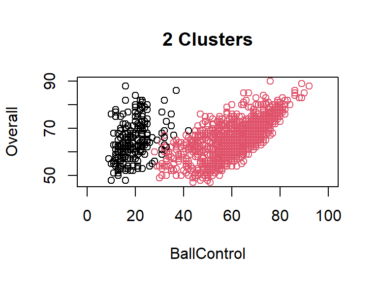

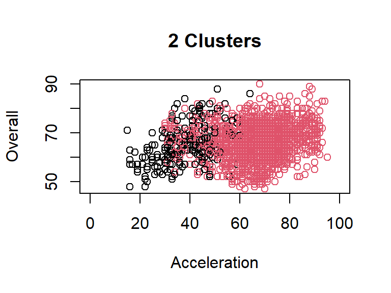

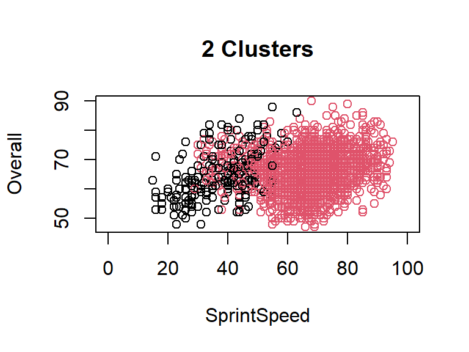

[22 more figures not shown]

```r
# run kmeans with
k = 2
cl <- kmeans(df2000[55:88], k, nstart = 25, iter.max = 20)
# create scatterplots
for (i in 55:88) {
  plot(df2000[ , i], df2000[, 8], col = cl$cluster,  main = paste(k, "Clusters", sep = " "), xlim = c(0, 100), tl = .5,
        xlab = colnames(df2000)[i], ylab = colnames(df2000)[8])  # all data points colored by cluster
}
```

# Separate the data into two subsets: goal keepers and the rest players

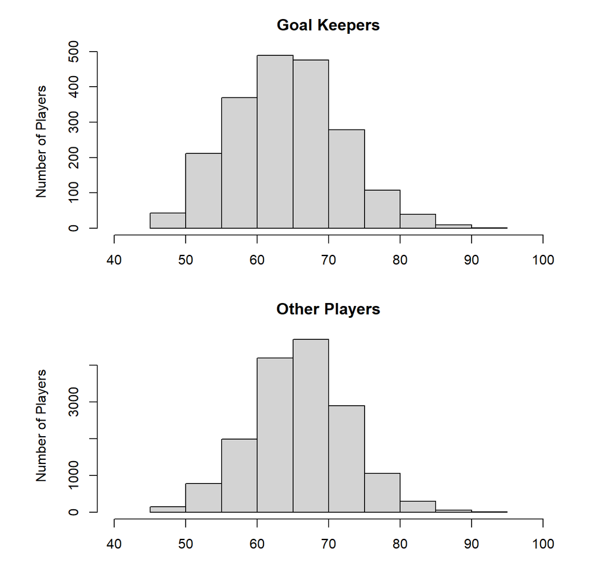

```r
# separate dataset into "GK" and "Non-GK" clusters
df_gk <- df[df$Position == "GK", ]     # GK / goal keepers
df_rest <- df[df$Position != "GK", ]   # rest (Not GK / non-goalkeepers)

# histogram
par(mfrow = c(2,1), mar = c(3,6,3,3))
hist(df_gk$Overall, main = "Goal Keepers", ylab = "Number of Players", xlim = c(40, 100),
     xlab = " ")
hist(df_rest$Overall, main = "Other Players", ylab = "Number of Players",  xlim = c(40, 100),
     xlab = "Overall Rating Scale of 100")
```

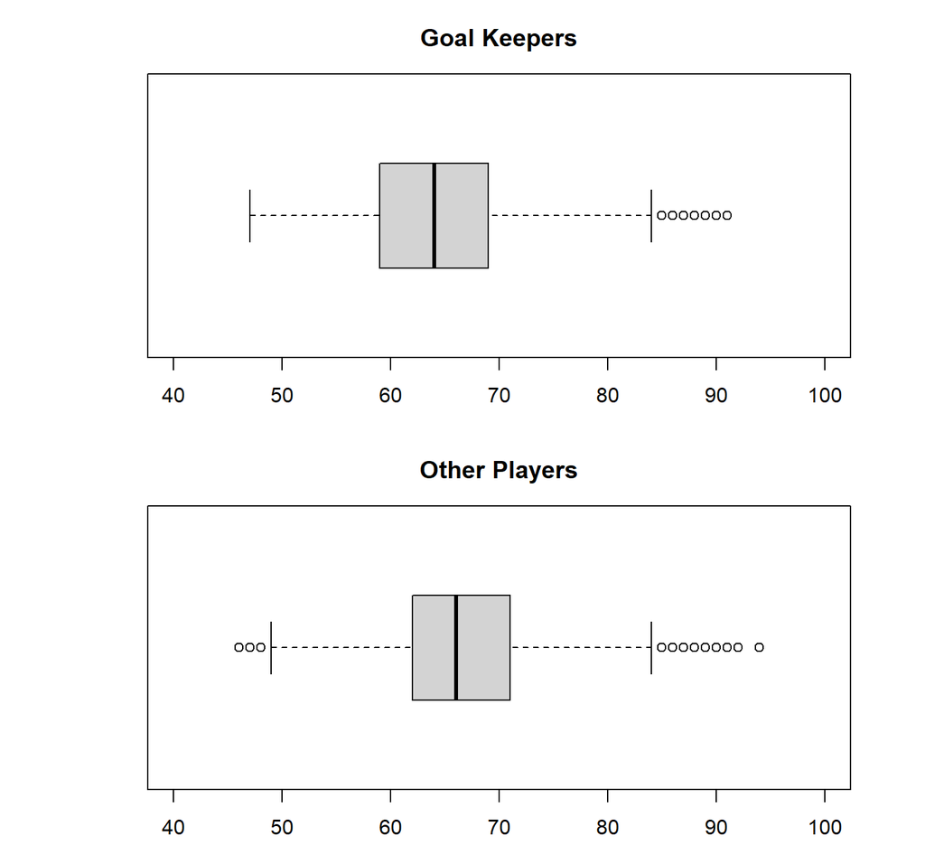

```r
# boxplot
boxplot(df_gk$Overall, main = "Goal Keepers", xlab = " ", ylim = c(40, 100), horizontal = TRUE)
boxplot(df_rest$Overall, main = "Other Players",  xlab = "Overall Rating Scale of 100", ylim = c(40, 100), horizontal = TRUE)
```

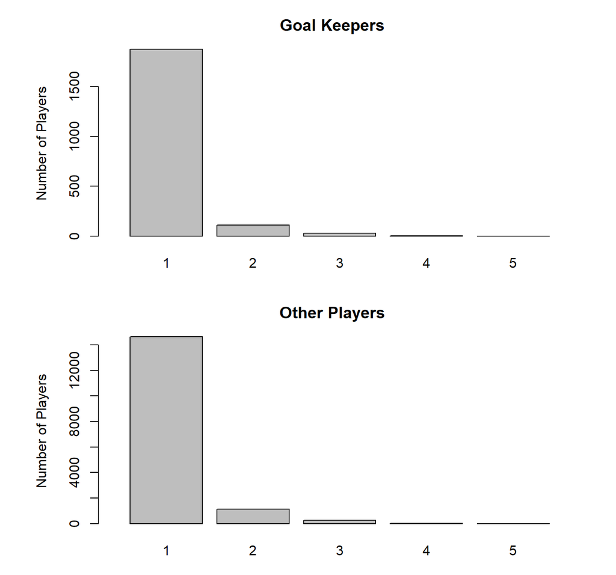

```r
# International Reputation Rating
plot(df_gk$International.Reputation, xlab = "Int'l Reputation Scale of 5", ylab = "Number of Players",
     main = "Goal Keepers", xlim = c(0, 6))
plot(df_rest$International.Reputation, xlab = "Int'l Reputation Scale of 5", ylab = "Number of Players",
     main = "Other Players", xlim = c(0, 6))
```

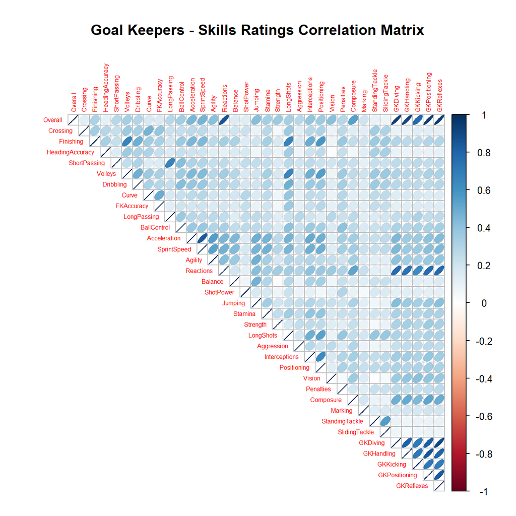

```r
# create corrplot of the numeric columns / skills of the goalkeepers set
# df_gk_skills <- df_gk[55:88]
N <- cor(cbind.data.frame(df_gk[8], df_gk[55:88]))
corrplot(N, method = "ellipse", type = "upper", tl.cex = .5,
         title = "Goal Keepers - Skills Ratings Correlation Matrix", mar = c(1, 1, 4, 1))
```

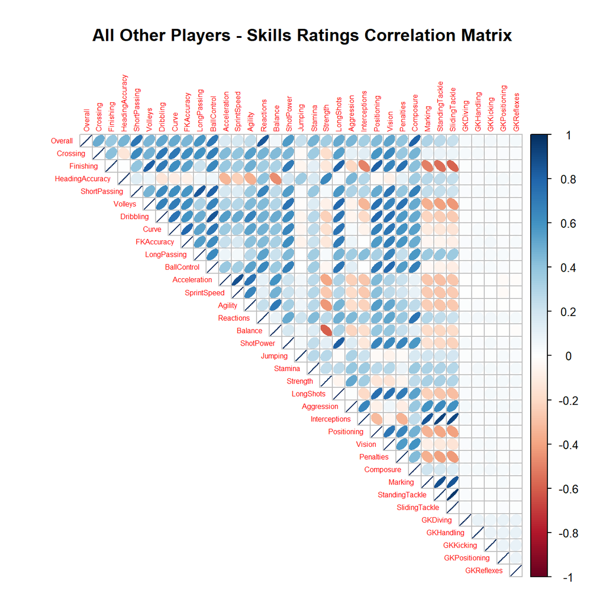

```r
# create corrplot of the numeric columns / skills of the rest players set
# df_rest_skills <- df_rest[55:88]
M <- cor(cbind.data.frame(df_rest[8], df_rest[55:88]))
corrplot(M, method = "ellipse", type = "upper", tl.cex = .5,
         title = "All Other Players - Skills Ratings Correlation Matrix", mar = c(1, 1, 4, 1))
```

# Discussion

The corrplots of the two distinct clusters reveal interesting observations. The corrplot for the goal keepers cluster shows that their corrlation coefficients are mostly in the postive range and that a few attribute ratings are strongly correlated. Principal Component Analysis (CPA) will be able to reduce the dimensions of the dataset by down-select skills that are strongly correlated before fitting any ML models.

On the other hand, the corrplot for the rest players shows that the values of the correlation coefficients are all over the place (ranging from the negative to the positive). That is reasonable since a player should be trained for skills set and hence acquire skills that are specific to the player’s position. That is, specific skill set is needed for particular positions, such as defensive midfielders (LDM, CDM and RDM), wings (RW and LW), midfielders (LM, CM and RM), attacking midfielders (LAM, CAM and RAM), and forwards (LF, CF and RF), etc. PCA conducted on this larger group should lead to different results than the goal keepers (GK) group. Thus, a different ML model is needed for prediction.

# Research questions:

For goalkeepers (GK), of the 34 skill ratings, how many are important to fit a good ML model to predict the overall rating and International Reputation Rating? Could any of the skill ratings be excluded without much adverse effect?

# Partition data into training and validation set

```r
# Need more observations of goal keepers.  Read in all data again for re-sampling for training and testing data
df <- read.csv(file = 'data.csv')
df$International.Reputation <- as.factor(df$International.Reputation)
df$International.Reputation <- as.ordered(df$International.Reputation)
df_gk <- df[df$Position == "GK",]

# split data, keeping same ratio of Int'l Reputation in both subsets
set.seed(5)
split = sample.split(df_gk$International.Reputation, SplitRatio = 0.75)
df_gk_train = subset(df_gk, split == TRUE)
df_gk_test = subset(df_gk, split == FALSE)
rm(split)
```

# Run PCA (prcomp) on Numeric Columns (Skill Ratings) of Goal Keepers dataset

```r
pca_gk <- prcomp(df_gk_train[ , 55:88], center = TRUE, scale. = TRUE)  # PCA on goal keepers training data
summary(pca_gk)   # summary of PCA results
```

```
## Importance of components:
##                           PC1    PC2     PC3    PC4     PC5     PC6     PC7
## Standard deviation     3.2441 1.8719 1.31565 1.2894 1.11204 1.07279 1.01624
## Proportion of Variance 0.3095 0.1031 0.05091 0.0489 0.03637 0.03385 0.03037
## Cumulative Proportion  0.3095 0.4126 0.46351 0.5124 0.54878 0.58263 0.61300
##                            PC8     PC9    PC10    PC11    PC12    PC13    PC14
## Standard deviation     0.99878 0.93904 0.89667 0.87210 0.84676 0.82584 0.80645
## Proportion of Variance 0.02934 0.02594 0.02365 0.02237 0.02109 0.02006 0.01913
## Cumulative Proportion  0.64234 0.66828 0.69193 0.71430 0.73539 0.75544 0.77457
##                           PC15   PC16    PC17    PC18    PC19   PC20    PC21
## Standard deviation     0.80002 0.7844 0.75170 0.74136 0.73414 0.7022 0.68406
## Proportion of Variance 0.01882 0.0181 0.01662 0.01617 0.01585 0.0145 0.01376
## Cumulative Proportion  0.79340 0.8115 0.82812 0.84428 0.86013 0.8746 0.88840
##                           PC22    PC23   PC24    PC25    PC26    PC27   PC28
## Standard deviation     0.66501 0.65807 0.6467 0.60141 0.58085 0.56999 0.5530
## Proportion of Variance 0.01301 0.01274 0.0123 0.01064 0.00992 0.00956 0.0090
## Cumulative Proportion  0.90141 0.91414 0.9264 0.93708 0.94700 0.95656 0.9656
##                           PC29    PC30    PC31    PC32    PC33    PC34
## Standard deviation     0.53962 0.50894 0.47057 0.40198 0.37126 0.31627
## Proportion of Variance 0.00856 0.00762 0.00651 0.00475 0.00405 0.00294
## Cumulative Proportion  0.97412 0.98174 0.98825 0.99300 0.99706 1.00000
```

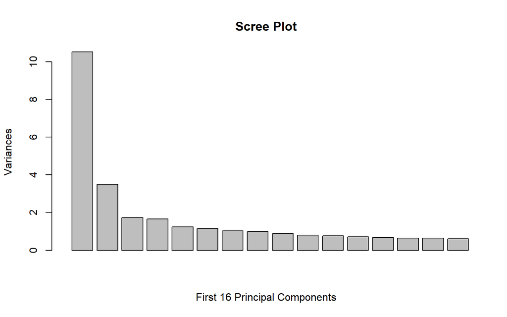

```r
# create screeplot for first 16 principal components that account for > 80% variance
screeplot(pca_gk, main = "Scree Plot", type = c("barplot", "lines"), npc = 16,
          xlab = "First 16 Principal Components", xlim = c(0,19))
```

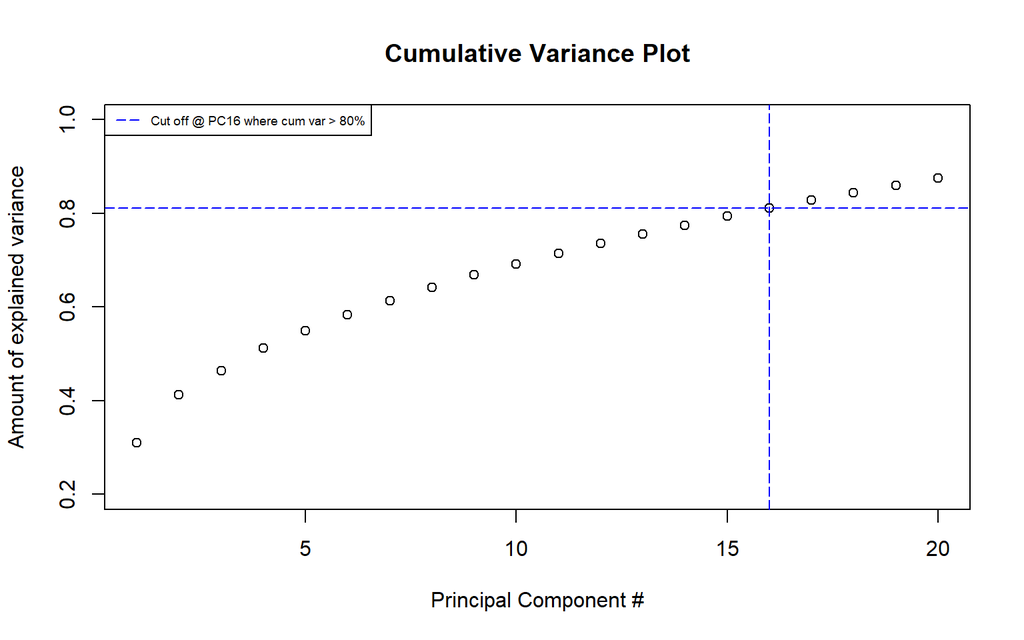

```r
# plot aumulative variance
cumpro <- cumsum(pca_gk$sdev^2 / sum(pca_gk$sdev^2))
plot(cumpro[1:20], xlab = "Principal Component #", ylab = "Amount of explained variance", main = "Cumulative Variance Plot",
     xlim = c(1, 20), ylim = c(0.2, 1))
abline(v = 16, col = "blue", lty = 5)
abline(h = 0.8115, col = "blue", lty = 5)
legend("topleft", legend = c("Cut off @ PC16 where cum var > 80%"), col = c("blue"), lty = 5, cex = 0.6)
```